# Lab: Week 9 – Solutions

36-350 – Statistical Computing

Week 9 – Spring 2021

Name: Mohamed Farag

Andrew ID: mfarag

## Question 1

*(5 points)*

*Notes 9A (2)*

```r
mu = c(2,2)
x = c(1,1)
sigma = c(1,1)
Sigma = matrix(c(sigma[1]^2,0,0,sigma[2]^2),2,2)
d = 2
(fx = exp(-0.5*t(x-mu)%*%solve(Sigma)%*%(x-mu))/sqrt((2*pi)^d*det(Sigma)))
```

```
##            [,1]
## [1,] 0.05854983
```

## Question 2

*(5 points)*

*Notes 9A (3)*

Verify your answer for Q1 using `dmvnorm()`.

```r
if ( require(emdbook) == FALSE ) {
  install.packages("emdbook",repos="https://cloud.r-project.org")
  library(emdbook)
}
dmvnorm(c(1,1),mu,Sigma)
```

```
## [1] 0.05854983
```

## Question 3

*(5 points)*

*Notes 9A (3)*

Use `persp()` to display your bivariate normal from Q1 and Q2. The inputs are `x`, `y`, and `z`, where `x` and `y` are vectors indicating the input values to `dmvnorm()` (think: sequences where the steps are small enough so that the displayed bivariate surface is smooth), and `z` is a matrix of output values. The simplest approach here is to use nested `for` loops to compute each value for `z`. In your call to `persp()`, set the arguments `theta` and `phi` to 45 and 30, respectively.

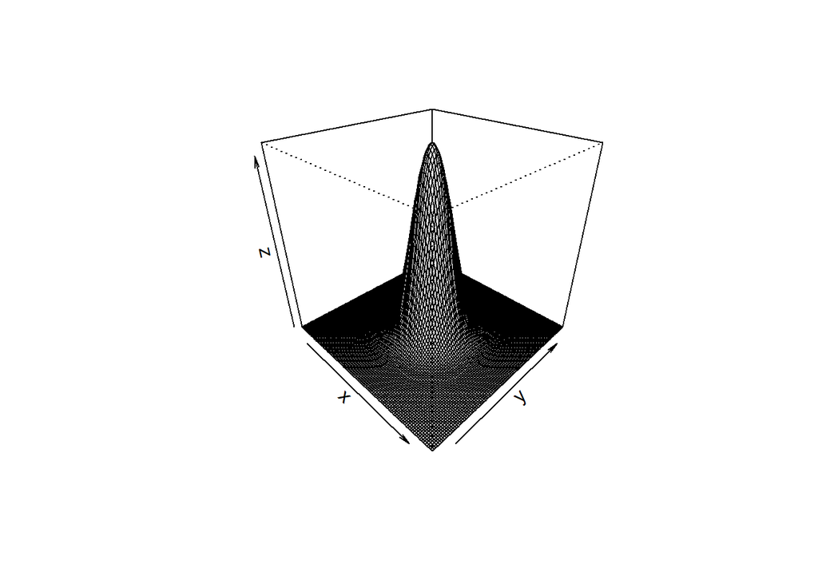

```r
x = seq(-3,7,by=0.1)
y = seq(-3,7,by=0.1)
z = matrix(NA,length(x),length(y))
for ( ii in 1:length(x) ) {
  for ( jj in 1:length(y) ) {
    z[ii,jj] = dmvnorm(c(x[ii],y[jj]),mu,Sigma)
  }
}
persp(x,y,z,theta=45,phi=30)
```

## Question 4

*(5 points)*

*Notes 9A (3)*

Repeat Q3, except change the bivariate normal to have correlation coefficient $\rho = 0.5$. Show two perspective plots, one with (`theta`,`phi`) = (45,30), and one with values (-45,30). You should be able to see the effects of the non-zero correlation coefficient as you toggle between the two plots.

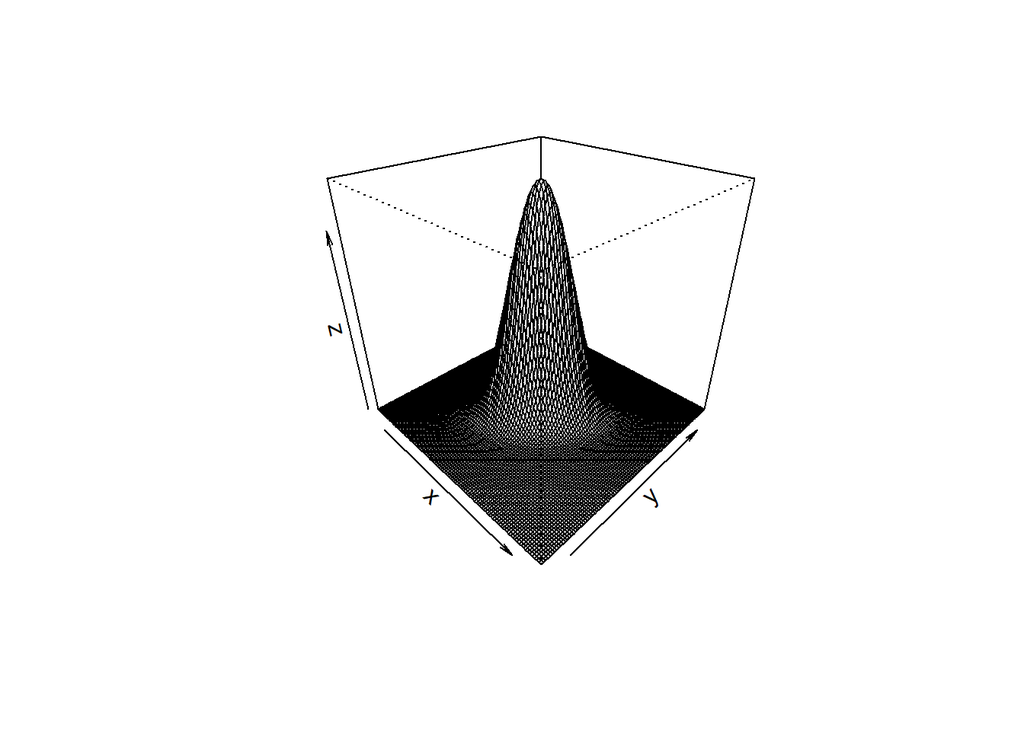

```r
Sigma = matrix(c(sigma[1]^2,0.5*sigma[1]*sigma[2],0.5*sigma[1]*sigma[2],sigma[2]^2),2,2)
for ( ii in 1:length(x) ) {
  for ( jj in 1:length(y) ) {
    z[ii,jj] = dmvnorm(c(x[ii],y[jj]),mu,Sigma)
  }
}
persp(x,y,z,theta=45,phi=30)
```

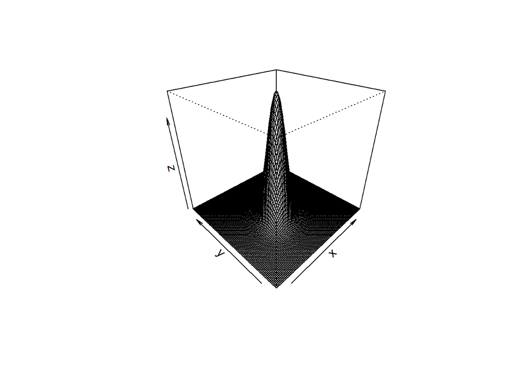

```r
persp(x,y,z,theta=-45,phi=30)
```

## Question 5

*(5 points)*

*Notes 9A (3)*

Use `contour()` to create a contour plot of the multivariate normal from Q4. Because $\rho > 0$, you should see that the contours are “tilted” so that they are lower on the left and higher on the right.

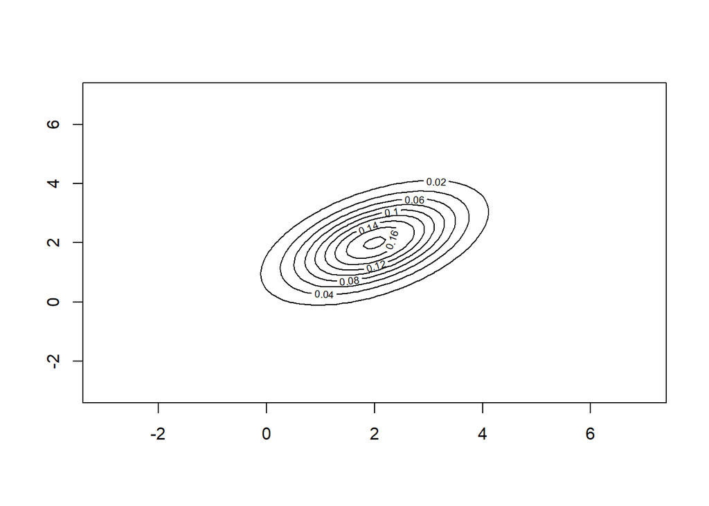

```r
contour(x,y,z)
```

## Question 6

*(5 points)*

*Notes 9A (4)*

Sample 1000 data from a bivariate normal with $\mu = \{1,3\}$, $\sigma = \{2,1\}$, and $\rho = -0.75$, and plot your sampled points using `ggplot`.

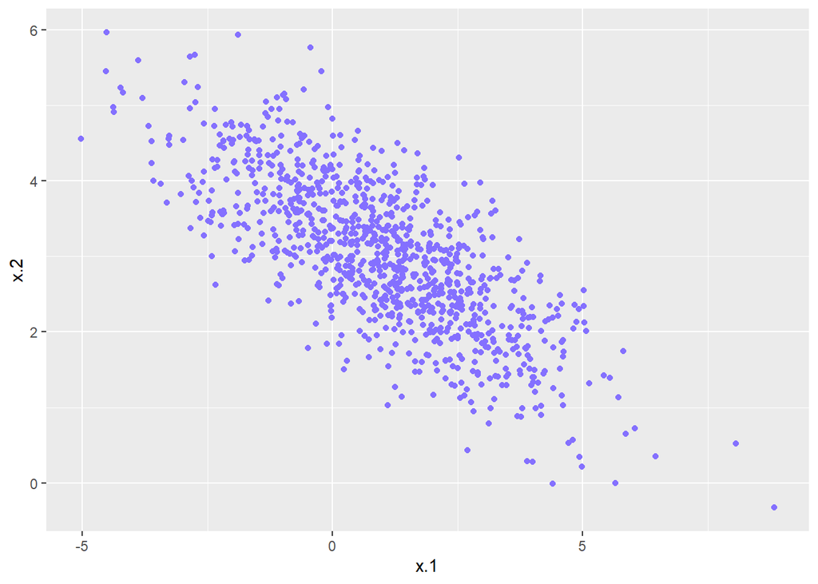

```r
suppressMessages(library(MASS))
library(ggplot2)
mu = c(1,3)
sigma = c(2,1)
rho = c(1,-0.75,-0.75,1)
Sigma = rho * (sigma %o% sigma)
set.seed(505)
data = data.frame(mvrnorm(1000,mu,Sigma))
names(data) = c("x.1","x.2")
ggplot(data=data,mapping=aes(x=x.1,y=x.2)) + geom_point(col="lightslateblue")
```

## Question 7

*(5 points)*

*Notes 9A (5)*

Display both the population covariance matrix and the sample covariance matrix (given your sample from Q6). The take-away point here is that the elements of the sample covariance matrix are random variables! (Whose values are hopefully close to those of the population matrix.)

```r
Sigma
```

```
##      [,1] [,2]
## [1,]  4.0 -1.5
## [2,] -1.5  1.0
```

```r
cov(data)
```

```
##           x.1        x.2
## x.1  3.836638 -1.4563048
## x.2 -1.456305  0.9936023
```

You are given the following multivariate normal:

```r
mu = c(1,2,6,2,-4)
sigma = c(1,2,1,0.5,2)
rho = diag(rep(1,5))
rho[1,2] = rho[2,1] = 0.4
rho[1,3] = rho[3,1] = -0.3
rho[1,4] = rho[4,1] = -0.7
rho[3,5] = rho[5,3] = 0.2
rho[4,5] = rho[5,4] = 0.5
Sigma = rho * (sigma %o% sigma)
```

## Question 8

*(5 points)*

*Notes 9A (4)*

Sample 100 data from this distribution. Display your sampled data via the `pairs()` function, which generates a pairwise grid of scatterplots. Change the labels on the `pairs()` plot to “x.1”, “x.2”, …, “x.5”. Also, apply the argument `pch=19`.

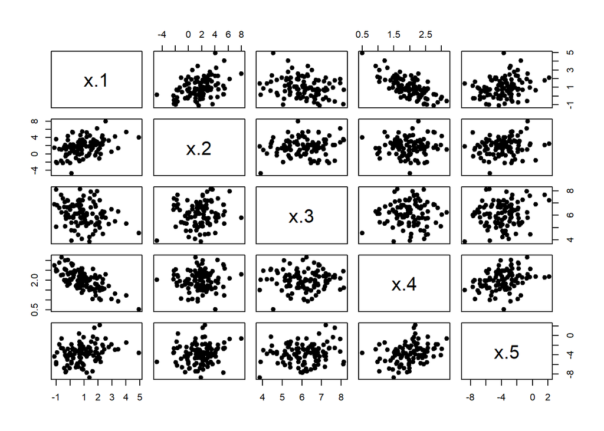

```r
data = mvrnorm(100,mu,Sigma)
pairs(data,labels=c("x.1","x.2","x.3","x.4","x.5"),pch=19)
```

## Question 9

*(5 points)*

*Notes 9A (4,6)*

Sample 100 data from the marginal distribution $f(x_1,x_5)$. Plot your result with either a base `R` or `ggplot` plotting function.

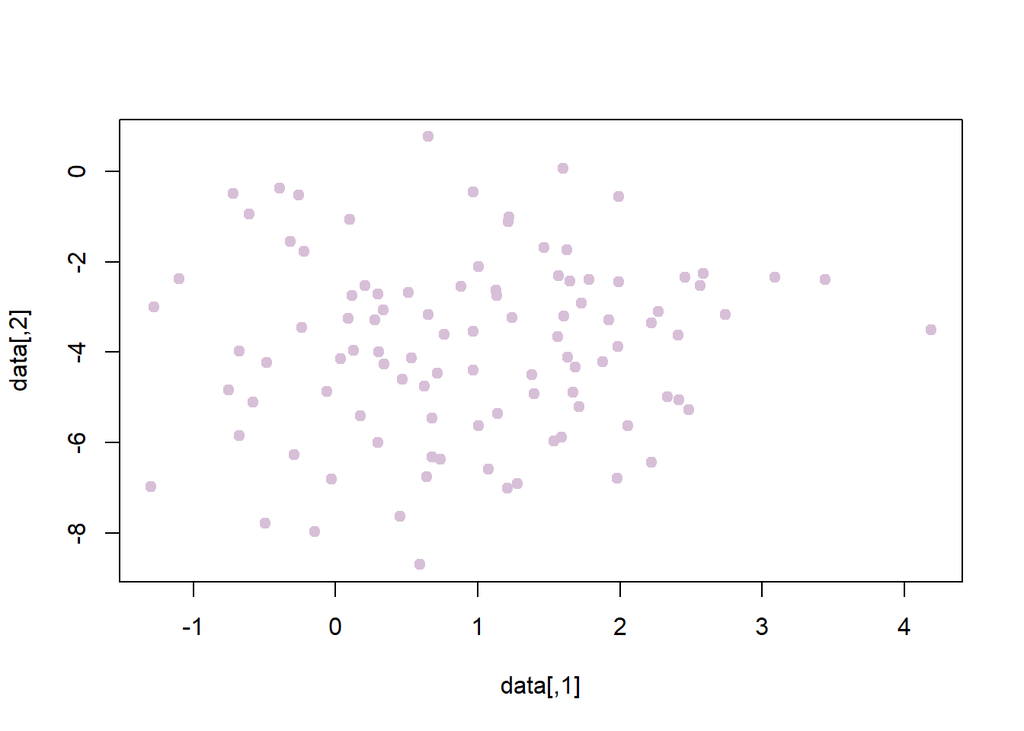

```r
mu.marg = mu[c(1,5)]
Sigma.marg = Sigma[c(1,5),c(1,5)]
data = mvrnorm(100,mu.marg,Sigma.marg)
plot(data,pch=19,col="thistle")
```

## Question 10

*(5 points)*

*Notes 9A (7-8)*

Compute the mean and the covariance matrix for $f(x_2,x_3 \vert x_1=1,x_4=1,x_5=1)$. Display your results.

```r
Sigma.kk = Sigma[2:3,2:3]
Sigma.kd = Sigma[2:3,c(1,4:5)]
Sigma.dk = Sigma[c(1,4:5),2:3]
Sigma.dd = Sigma[c(1,4:5),c(1,4:5)]

(mu.cond = mu[2:3] + Sigma.kd %*% solve(Sigma.dd) %*% matrix(c(1,1,1)-mu[c(1,4:5)]))
```

```
##        [,1]
## [1,] -5.000
## [2,] 10.375
```

```r
(Sigma.cond = Sigma.kk - Sigma.kd %*% solve(Sigma.dd) %*% Sigma.dk)
```

```
##           [,1]      [,2]
## [1,] 2.1538462 0.9076923
## [2,] 0.9076923 0.5003846
```

## Question 11

*(5 points)*

*Notes 9A (4,6)*

Sample 100 data from the conditional distribution $f(x_2,x_3 \vert x_1=1,x_4=1,x_5=1)$. Plot your result with either a base `R` or `ggplot` plotting function.

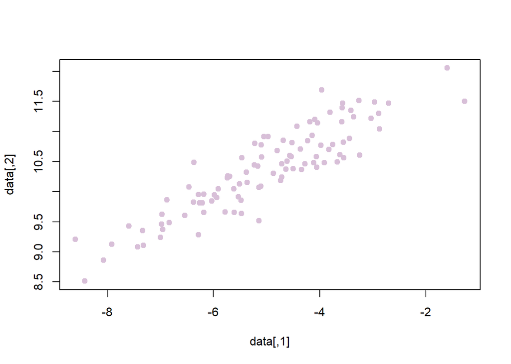

```r
data = mvrnorm(100,mu.cond,Sigma.cond)
plot(data,pch=19,col="thistle")
```

In the following code chunk, we input four morphological measurements for each of 3419 galaxies. The data frame is `df`.

```r
load(url("http://www.stat.cmu.edu/~mfarag/350/Lab_09_PCA.Rdata"))
names(df)
```

```
## [1] "G"    "M20"  "C"    "size"
```

## Question 12

*(5 points)*

*Not in Notes*

As you did in Q8, create a `pairs()` plot for the data frame `df`. Here, there is no need to change the labels, although you should still apply the argument `pch=19`…and since there are many points, also apply the argument `cex=0.2`, which shrinks the sizes of the points. Last, apply the argument `col=rgb(0,0,1,alpha=0.2)`: this changes the color of the points to blue (the “(0,0,1)” part of the function call), and makes them mostly transparent (the “alpha=0.2” part of the function call…a value of 1 is opaque). Two things should jump out at you: (1) the data are not distributed as a multivariate normal, and (2) there are definite correlations between at least some pairs of variables.

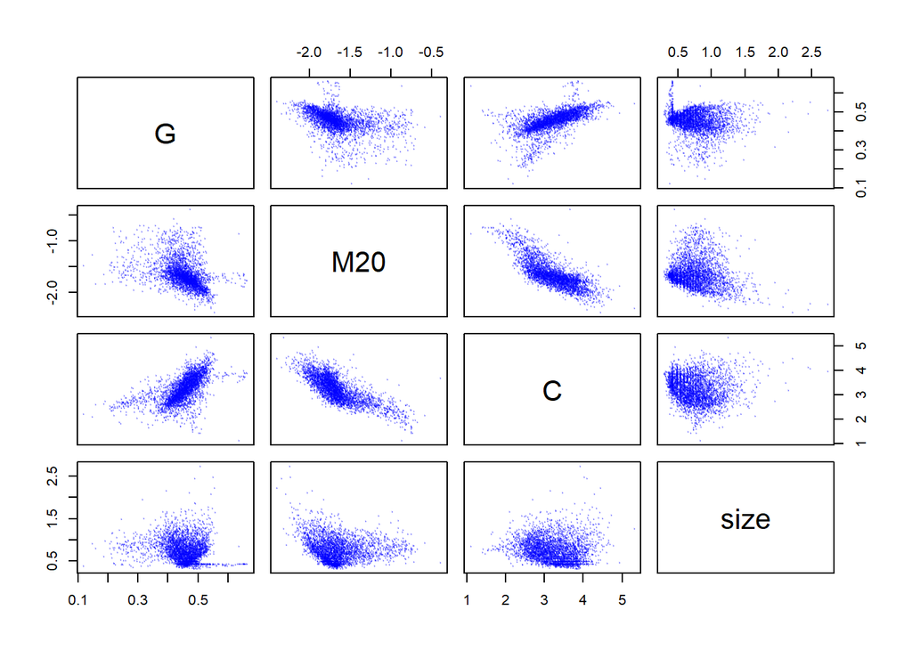

```r
pairs(df,pch=19,cex=0.2,col=rgb(0,0,1,alpha=0.2))
```

## Question 13

*(5 points)*

*Not in Notes*

Use the `scale()` function to scale the data frame `df`. By default, `scale()` will subtract the sample mean of each column’s data from the data values, then divide by the sample standard deviation. (In 36-225 talk, this is “standardizing” the data.) Save the scaled data frame as `df.scaled`. Confirm that the data are scaled by using `colMeans()` to check the sample means, and by using `apply()` with an appropriate function to check the sample standard deviations. (You may observe that the means are not exactly zero. This is normal.)

```r
df.scaled = scale(df)
colMeans(df.scaled)
```

```
##             G           M20             C          size
##  2.377008e-16 -2.196032e-16 -3.047423e-17 -4.943277e-17
```

```r
apply(df.scaled,2,sd)
```

```
##    G  M20    C size
##    1    1    1    1
```

## Question 14

*(5 points)*

*Notes 9B (4)*

Compute the eigenvectors and eigenvalues for the covariance matrix of `df.scaled`. Save these as `v` and `lambda`, respectively. Use `dim()` to display the dimensionality of the matrix `v` and `length()` to show the length of the vector `lambda`. Also check, using `all()` with a relational operator, that all the values of lambda are greater than zero. Finally, display `v` and the square root of `lambda`.

```r
e = eigen(cov(df.scaled))
v = e$vectors
lambda = e$values
dim(v)
```

```
## [1] 4 4
```

```r
length(lambda)
```

```
## [1] 4
```

```r
all(lambda>0)
```

```
## [1] TRUE
```

```r
v
```

```
##             [,1]        [,2]       [,3]       [,4]
## [1,]  0.51461474 -0.21735992  0.8020834  0.2111600
## [2,] -0.57408998 -0.31096317  0.4453620 -0.6126788
## [3,]  0.63449159 -0.02505601 -0.2188305 -0.7408818
## [4,] -0.05488889  0.92489392  0.3323072 -0.1764379
```

```r
sqrt(lambda)
```

```
## [1] 1.4800888 1.0405683 0.7494448 0.4060633
```

## Question 15

*(5 points)*

*Notes 9B (5)*

Use matrix multiplication to multiply `df.scaled` and `v`. Save the result as `z`. Use `ggplot` to display a scatterplot for the first two columns of `z`. (You need not overlay lines like those in the plot of Slide 5 of Notes 9B.)

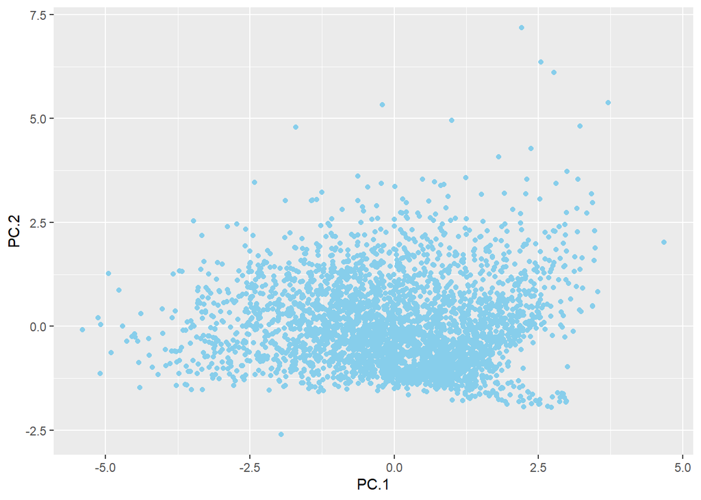

```r
z = data.frame(df.scaled %*% v)
names(z) = c("PC.1","PC.2","PC.3","PC.4")
ggplot(data=z,mapping=aes(x=PC.1,y=PC.2)) + geom_point(col="skyblue")
```

Congratulations! In Q13-Q15, you recreated principal components analysis by hand. Now let’s use `prcomp()`.

## Question 16

*(5 points)*

*Notes 9B (9)*

Use `prcomp()` to perform PCA on `df` directly. Divide the rotation matrix output by `prcomp()` by `v` from Q14, and the standard deviations (`sdev`) output by `prcomp()` by the square root of `lambda` (also from Q14). If you did everything right, you will see that the first division yields only values of $-1$ or $1$ (due to the arbitrariness of signs of the eigenvectors), and the second division yields only values of $1$.

```r
p = prcomp(df,scale=TRUE)
p$rotation/v
```

```
##      PC1 PC2 PC3 PC4
## G     -1   1  -1  -1
## M20   -1   1  -1  -1
## C     -1   1  -1  -1
## size  -1   1  -1  -1
```

```r
p$sdev/sqrt(lambda)
```

```
## [1] 1 1 1 1
```

## Question 17

*(5 points)*

*Notes 9B (9)*

Display the rotation matrix output by `prcomp()`. How does each principal component map to the original variables? (Each displayed principal component is a vector; the larger the value for a particular original variable, the more the vector points in that direction.)

```r
p$rotation
```

```
##              PC1         PC2        PC3        PC4
## G    -0.51461474 -0.21735992 -0.8020834 -0.2111600
## M20   0.57408998 -0.31096317 -0.4453620  0.6126788
## C    -0.63449159 -0.02505601  0.2188305  0.7408818
## size  0.05488889  0.92489392 -0.3323072  0.1764379
```

```
PC 1 maps roughly equally to the variables G, M20, and C,
and mostly excludes size.
PC 2 maps predominantly to size.
PC 3 maps predominantly to G.
PC 4 maps predominantly to M20 and C.
```

## Question 18

*(5 points)*

*Notes 9B (10)*

Create a plot showing the proporation of variance explained as a function of the number of principal components. (Use base `R` plotting.) Add a dashed line across the plot for proporation of variance explained equals 0.9. (See `abline()`.) How many principal components would you keep if you were attempting dimension reduction?

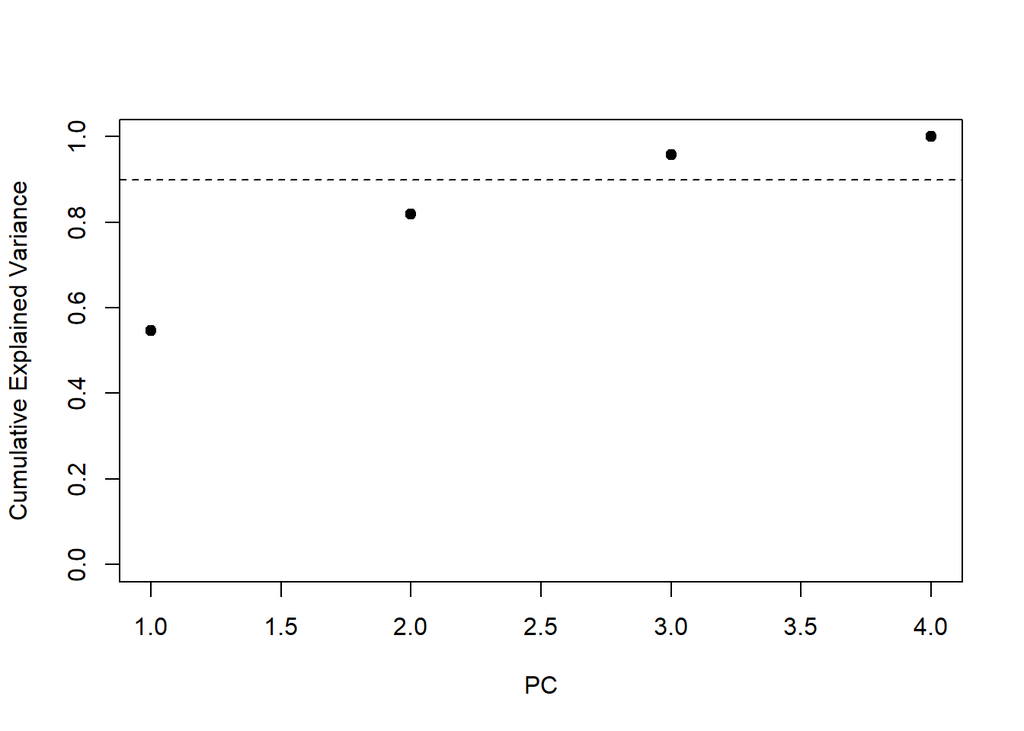

```
Using the 90% rule-of-thumb, I would retain the first three
principal components.
```

```r
plot(1:4,cumsum(p$sdev^2)/sum(p$sdev^2),pch=19,xlab="PC",ylab="Cumulative Explained Variance",ylim=c(0,1))
abline(h=0.9,lty=2)
```

## Question 19

*(5 points)*

*Not in Notes*

Determine which of the elements of the output from `prcomp()` corresponds to the principal component scores, then verify that the data in the score columns are uncorrelated.

```r
cor(p$x)
```

```
##              PC1           PC2           PC3           PC4
## PC1 1.000000e+00  7.539378e-16  3.070020e-15  4.597451e-15
## PC2 7.539378e-16  1.000000e+00 -9.176824e-16 -8.986795e-16
## PC3 3.070020e-15 -9.176824e-16  1.000000e+00 -2.130108e-15
## PC4 4.597451e-15 -8.986795e-16 -2.130108e-15  1.000000e+00
```

## Question 20

*(5 points)*

*Notes 9B (11)*

Using base `R` plotting functionality, plot the first two principal component scores, and color the data by the value of `df$size`. Because PC 2 points almost completely along the `size` axis, you should see a definite gradient in color as you go from the bottom to the top of your plot.

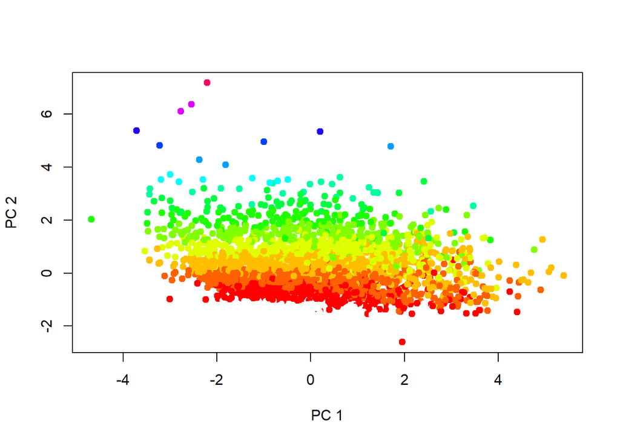

```r
s = df$size
palette(rainbow(16))
plot(p$x[,1],p$x[,2],pch=19,xlab="PC 1",ylab="PC 2",col=16*(s-min(s))/(max(s)-min(s)))
```